# What Goes Into Fuel Efficiency?

Hannah Peterson

5/13/2022

```r
library(fueleconomy)
library(tidyverse)
library(tidymodels)
library(rpart.plot)
library(patchwork)
```

# Introduction

With fuel prices skyrocketing recently, some people *might* be thinking about their car’s fuel efficiency more than normal.

**What factors determine/affect a cars gas efficiency? Can we predict the MPG given these factors?**

Let’s look at a snippet of the `Vehicles` dataset from the `fueleconomy`package:

```r
vehicles
```

```
## # A tibble: 33,442 × 12
##       id make  model        year class trans drive   cyl displ fuel    hwy   cty
##    <dbl> <chr> <chr>       <dbl> <chr> <chr> <chr> <dbl> <dbl> <chr> <dbl> <dbl>
##  1 13309 Acura 2.2CL/3.0CL  1997 Subc… Auto… Fron…     4   2.2 Regu…    26    20
##  2 13310 Acura 2.2CL/3.0CL  1997 Subc… Manu… Fron…     4   2.2 Regu…    28    22
##  3 13311 Acura 2.2CL/3.0CL  1997 Subc… Auto… Fron…     6   3   Regu…    26    18
##  4 14038 Acura 2.3CL/3.0CL  1998 Subc… Auto… Fron…     4   2.3 Regu…    27    19
##  5 14039 Acura 2.3CL/3.0CL  1998 Subc… Manu… Fron…     4   2.3 Regu…    29    21
##  6 14040 Acura 2.3CL/3.0CL  1998 Subc… Auto… Fron…     6   3   Regu…    26    17
##  7 14834 Acura 2.3CL/3.0CL  1999 Subc… Auto… Fron…     4   2.3 Regu…    27    20
##  8 14835 Acura 2.3CL/3.0CL  1999 Subc… Manu… Fron…     4   2.3 Regu…    29    21
##  9 14836 Acura 2.3CL/3.0CL  1999 Subc… Auto… Fron…     6   3   Regu…    26    17
## 10 11789 Acura 2.5TL        1995 Comp… Auto… Fron…     5   2.5 Prem…    23    18
## # … with 33,432 more rows
```

This dataset, as described by its R documentation, includes “fuel economy data from the EPA, 1985-2015. This dataset contains selected variables, and removes vehicles with incomplete data (e.g. no drive train data).” The variable names are pretty self explanatory, but let’s look at how they’re defined:

- **id**: Unique EPA identifier
- **make**: Manufacturer
- **model**: Model name
- **year**: Model year
- **class**: EPA vehicle size class, http://www.fueleconomy.gov/feg/ws/wsData.shtml#VClass
- **trans**: Transmission
- **drive**: Drive train
- **cyl**: Number of cylinders
- **displ**: Engine displacement, in litres
- **fuel**: Fuel type
- **hwy**: Highway fuel economy, in mpg
- **cty**: City fuel economy, in mpg

# Data Cleaning

First, let’s get a singular number for fuel economy by taking the average of `cty` and `hwy`. We’ll add this to a new column called `mpg`

```r
vehicles = vehicles %>%
  mutate(mpg = (cty + hwy)/2)
```

Let’s look at our fuel types in the dataset:

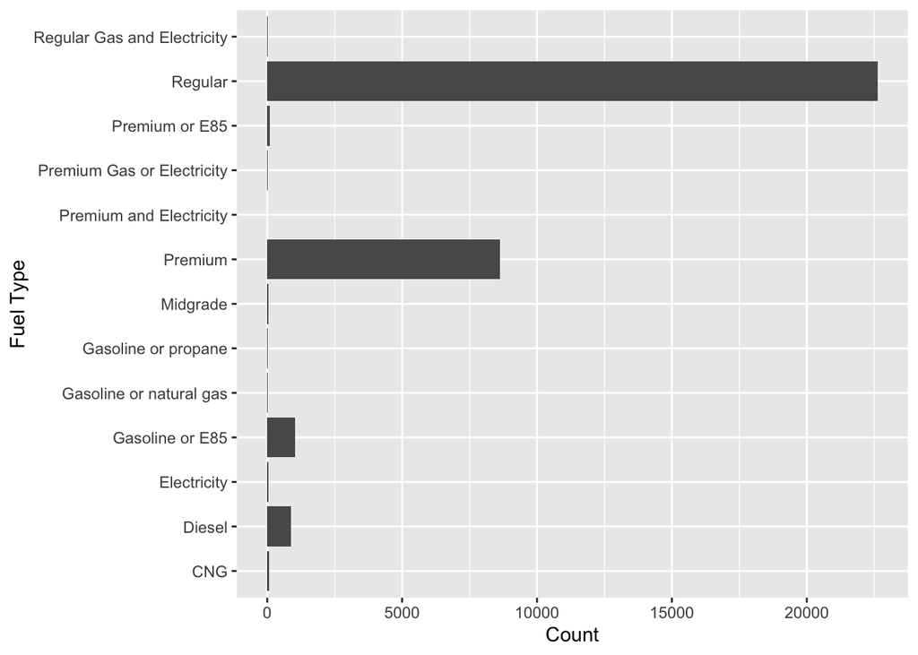

```r
vehicles %>%
  ggplot(aes(x = fuel)) +
  geom_bar() +
  labs(x = "Fuel Type", y = "Count") +
  coord_flip()
```

The `fuel` column has lots of different, very specific types, so let’s simplify a bit by adding a column called `fuel_simp`:

```r
vehicles = vehicles %>%
  mutate(fuel_simp = case_when(fuel %in% c("Premium", "Regular", "Gasoline or E85", "Midgrade", "Gasoline or propane", "Gasoline or natural gas", "Premium or E85") ~ "Gas", fuel %in% c("Regular Gas and Electricity", "Premium Gas or Electricity", "Premium and Electricty") ~ "Hybrid", fuel == "Electricity" ~ "Electric", fuel == "Diesel" ~ "Diesel", fuel == "CNG" ~ "CNG"))
```

Let’s see how that looks now…

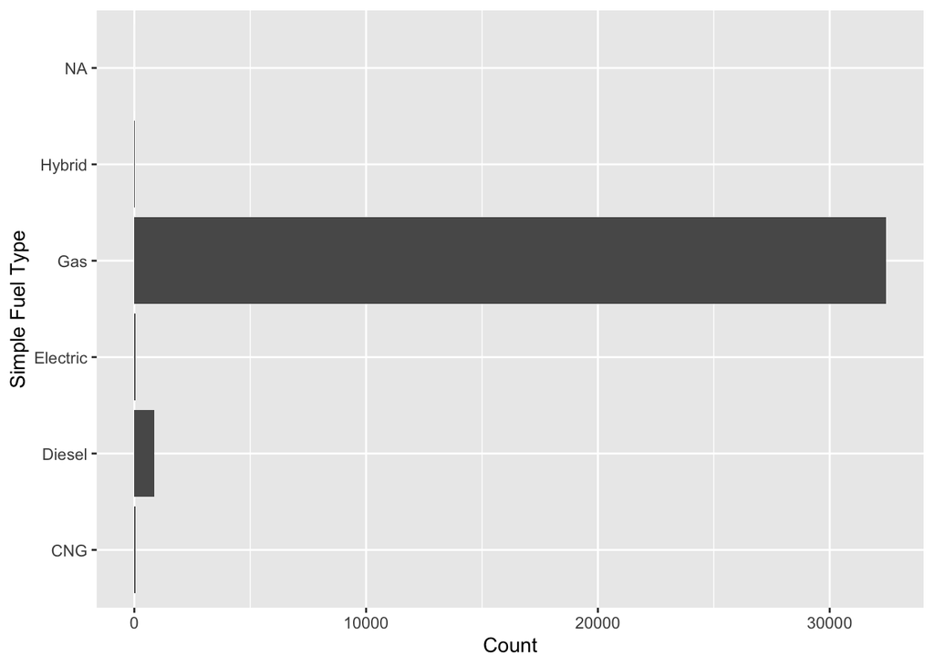

```r
vehicles %>%
  ggplot(aes(x = fuel_simp)) +
  geom_bar() +
  labs(x = "Simple Fuel Type", y = "Count") +
  coord_flip()
```

Since MPG is about gallons of fuel, let’s filter our data to include everything but electric cars. **Note:** Electric cars do have values for `hwy` and `cty`, but 1. They don’t actually use ‘gallons’ of electricity and 2. The documentation for the package doesn’t explain what these numbers mean

```r
vehicles_new = vehicles %>%
  filter(fuel_simp != "Electric")
```

# Exploratory Steps!

Now, lets get a visual of some things that might affect mpg for cars with a fuel type of gasoline:

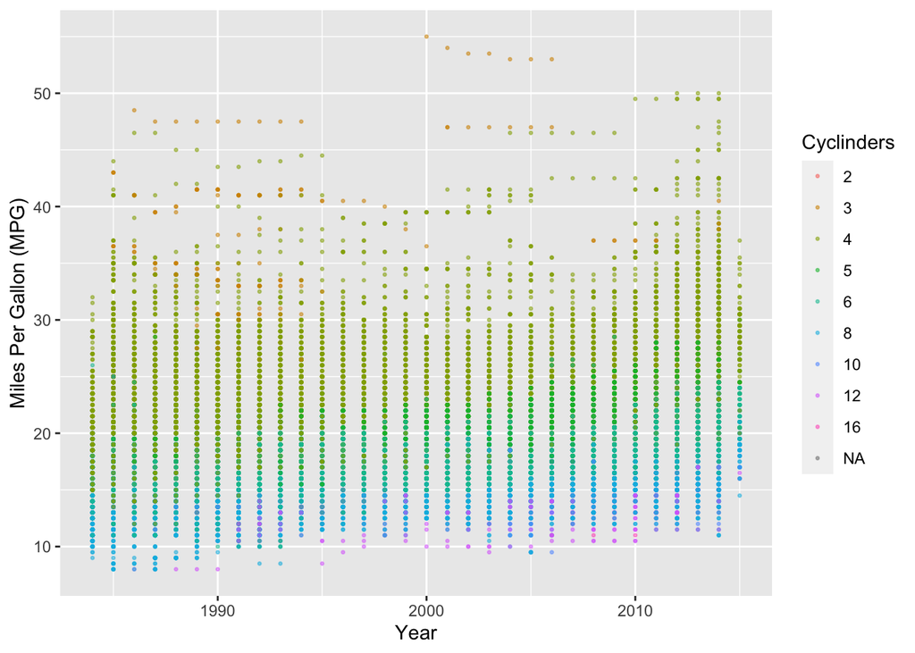

```r
vehicles_new %>%
  ggplot(aes(x = year, y = mpg, color = factor(cyl))) +
  geom_point(size = .5, alpha = .5) +
  labs(x = "Year", y = "Miles Per Gallon (MPG)", color = "Cyclinders")
```

From this visual, it seems that year and cylinders have an impact on average MPG!

What about `displ` and `fuel_simp`?

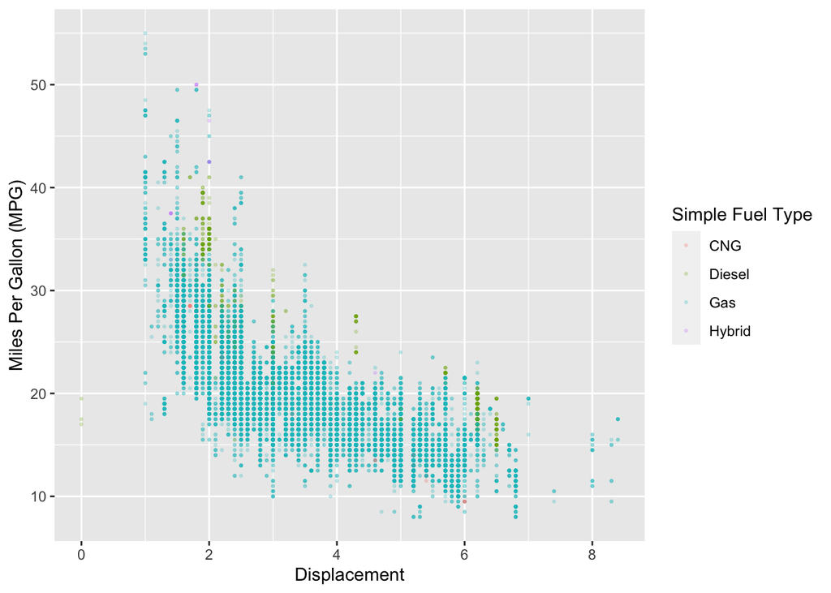

```r
vehicles_new %>%
  ggplot(aes(x = displ, y = mpg, color = fuel_simp)) +
  geom_point(size = .5, alpha = .2) +
  labs(x = "Displacement", y = "Miles Per Gallon (MPG)", color = "Simple Fuel Type")
```

# Predictive Models

## Linear Regression Model

Now let’s build a linear regression model:

```r
set.seed(64)

# 1. Data Splitting
vehicles_split = initial_split(vehicles_new)
vehicles_train = training(vehicles_split)
vehicles_test = testing(vehicles_split)
# 2. Fit Model
lm_fit =
  linear_reg() %>%
  fit(mpg ~ year + fuel_simp + cyl + displ,
    data = vehicles_train)
# 3. Generate Predictions
lm_pred = lm_fit %>%
  predict(new_data = vehicles_test)
# 4. Prediction Metric (RMSE)
vehicles_pred_lm = vehicles_test %>%
  select(displ, mpg, cyl, fuel_simp) %>%
  mutate(mpg_pred = lm_pred$.pred)
vehicles_pred_lm %>%
  rmse(estimate = mpg_pred, truth = mpg)
```

```
## # A tibble: 1 × 3
##   .metric .estimator .estimate
##   <chr>   <chr>          <dbl>
## 1 rmse    standard        2.89
```

Using `year`, `fuel_simp`, `cyl`, and `displ` to predict our target `mpg` in a linear regression model, our RMSE is 2.893449.

## Decision Tree Model

Let’s compare it to a decision tree model:

```r
set.seed(64)

# 2. Fit model
tree_fit =
  decision_tree() %>%
  set_mode(mode = "regression") %>%
  fit(mpg ~ year + fuel_simp + cyl + displ,
    data = vehicles_train)
# 3. Generate Predictions
tree_pred = tree_fit %>%
  predict(new_data = vehicles_test)
# 4. Prediction Metrics
vehicles_pred_tree = vehicles_test %>%
  select(displ, mpg, cyl, fuel_simp) %>%
  mutate(mpg_pred = tree_pred$.pred)
vehicles_pred_tree %>%
  rmse(truth = mpg, estimate = mpg_pred)
```

```
## # A tibble: 1 × 3
##   .metric .estimator .estimate
##   <chr>   <chr>          <dbl>
## 1 rmse    standard        2.67
```

Using `year`, `fuel_simp`, `cyl`, and `displ` to predict our target `mpg` in a decision tree model, our RMSE is 2.670114.

In our linear regression, the RMSE is 2.893449 and in our decision tree model the RMSE is 2.670114 – it seems like the decision tree model is just a slightly better fit!

# Visualizations

Let’s get a visual of what our decision tree looks like:

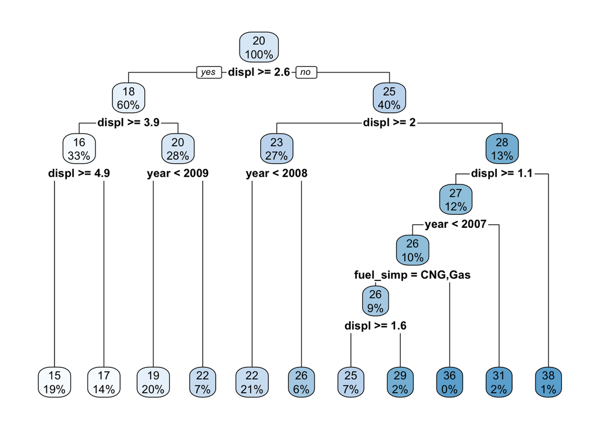

```r
rpart.plot(tree_fit$fit)
```

From this, we can see that displacement has the greatest affect on MPG, followed by year and fuel type.

Let’s visualize our predictions vs. our actual values for our linear model:

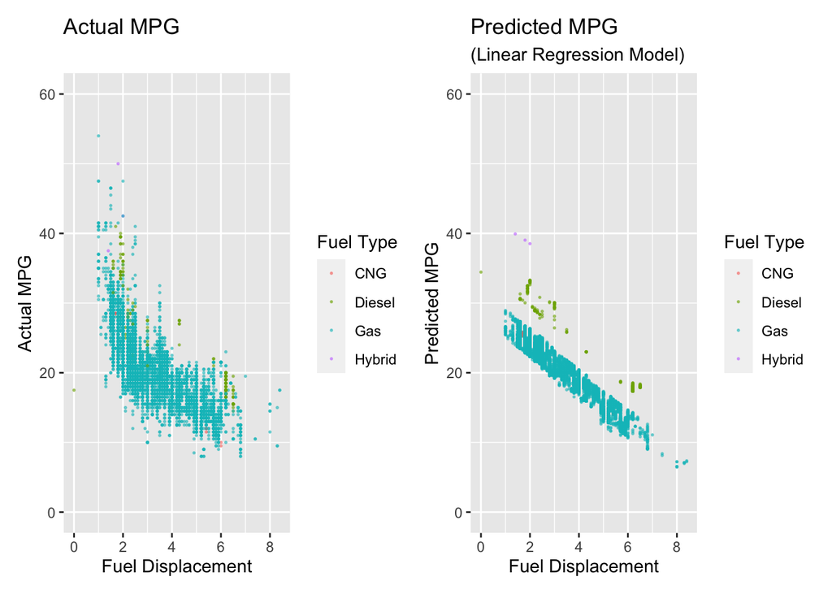

```r
# Patchwork package help from here:
# https://stackoverflow.com/questions/1249548/side-by-side-plots-with-ggplot2
actual_lm = ggplot(vehicles_pred_lm, aes(x = displ, y = mpg, color = fuel_simp, size = cyl)) +
  geom_point(size = .3, alpha = .5) +
  scale_y_continuous(limits = c(0, 60)) +
  labs(x = "Fuel Displacement", y = "Actual MPG", color = "Fuel Type", title = "Actual MPG")

predictions_lm = ggplot(vehicles_pred_lm, aes(x = displ, y = mpg_pred, color = fuel_simp, size = cyl)) +
  geom_point(size = .3, alpha = .5) +
  scale_y_continuous(limits = c(0, 60)) +
  labs(x = "Fuel Displacement", y = "Predicted MPG", color = "Fuel Type", title = "Predicted MPG", subtitle = "(Linear Regression Model)")

actual_lm + predictions_lm
```

Let’s visualize our predictions vs. our actual values for our decision model:

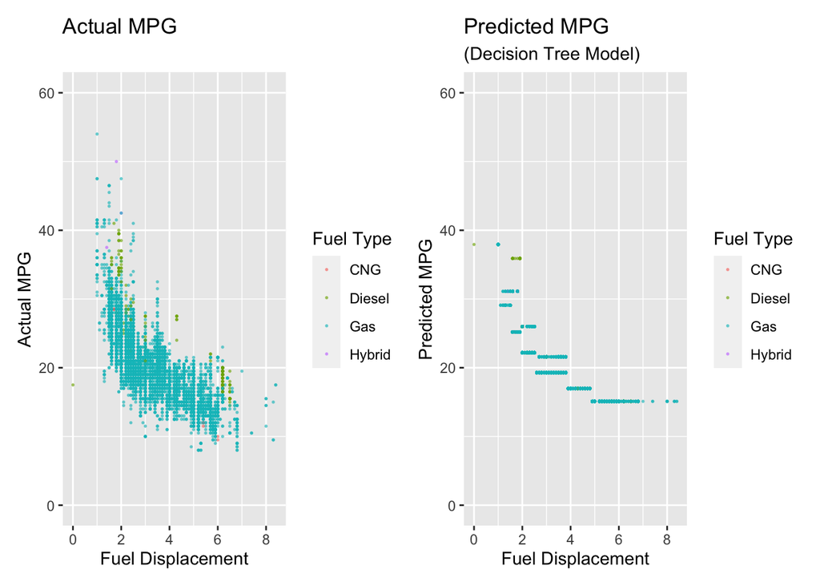

```r
actual_tree = ggplot(vehicles_pred_tree, aes(x = displ, y = mpg, color = fuel_simp, size = cyl)) +
  geom_point(size = .3, alpha = .5) +
  scale_y_continuous(limits = c(0, 60)) +
   labs(x = "Fuel Displacement", y = "Actual MPG", color = "Fuel Type", title = "Actual MPG")
predictions_tree = ggplot(vehicles_pred_tree, aes(x = displ, y = mpg_pred, color = fuel_simp, size = cyl)) +
  geom_point(size = .3, alpha = .5) +
  scale_y_continuous(limits = c(0, 60)) +
  labs(x = "Fuel Displacement", y = "Predicted MPG", color = "Fuel Type", title = "Predicted MPG", subtitle = "(Decision Tree Model)")
actual_tree + predictions_tree
```

# Conclusion

From our findings, it appears that when choosing a car based on its fuel efficiency, you’re also making a decision about its year, fuel type, cylinders, and displacement. More power means more fuel usage; while higher quality fuel like diesel is more efficient, it also costs more; and as technology advances throughout the years, fuel efficiency tends to advance too!